# Transport DEGs report (Metal / MDR / Nutrient / Other)

2026-04-09

## Executive summary

| comparison | total_transport | top_subcat | top_n | top_pct |
| --- | --- | --- | --- | --- |
| As_vs_Control | 96 | Other | 49 | 51 |
| As_vs_Cr | 288 | Other | 186 | 64.6 |
| Cr_vs_Control | 285 | Other | 181 | 63.5 |

## 1) Counts by subcategory

| comparison | MDR | Metal | Nutrient | Other |
| --- | --- | --- | --- | --- |
| As_vs_Control | 3 | 17 | 27 | 49 |
| As_vs_Cr | 12 | 23 | 67 | 186 |
| Cr_vs_Control | 12 | 30 | 62 | 181 |

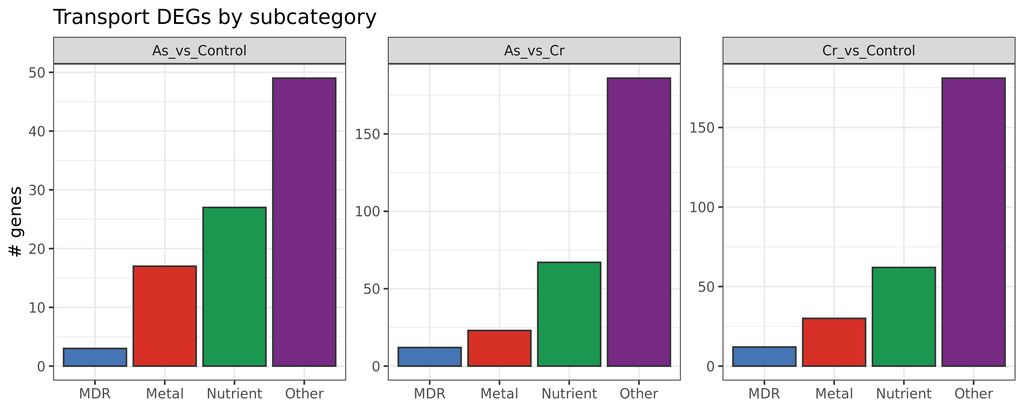

## 2) Plots per comparison

### As_vs_Control

**Summary:** 96 Transport DEGs. Volcano thresholds: `padj < 0.05` and `|log2FC| ≥ 1`.

[figure not shown]

[figure not shown]

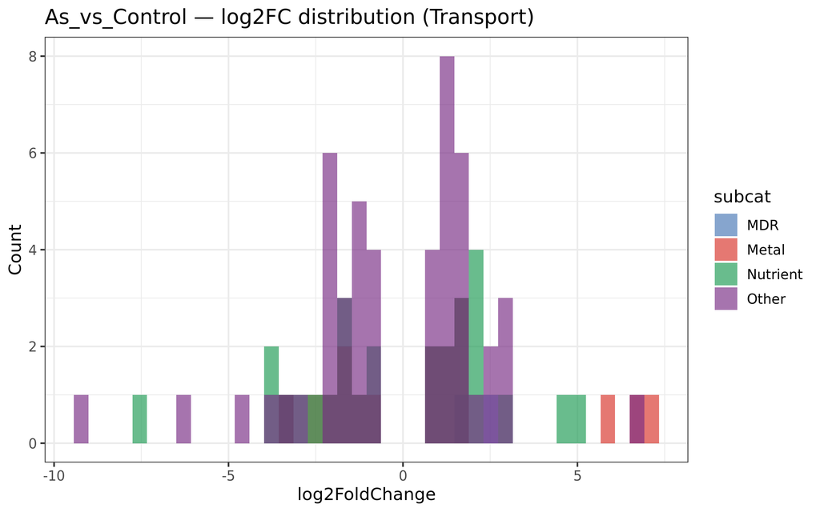

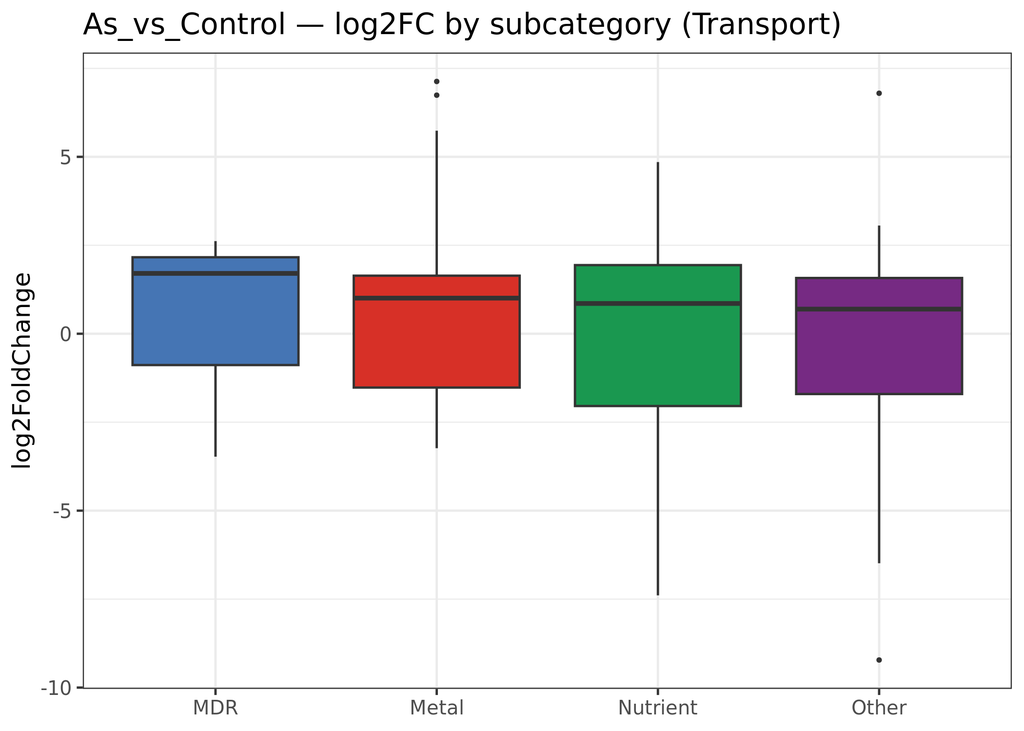

### Cr_vs_Control

**Summary:** 285 Transport DEGs. Volcano thresholds: `padj < 0.05` and `|log2FC| ≥ 1`.

[figure not shown]

[figure not shown]

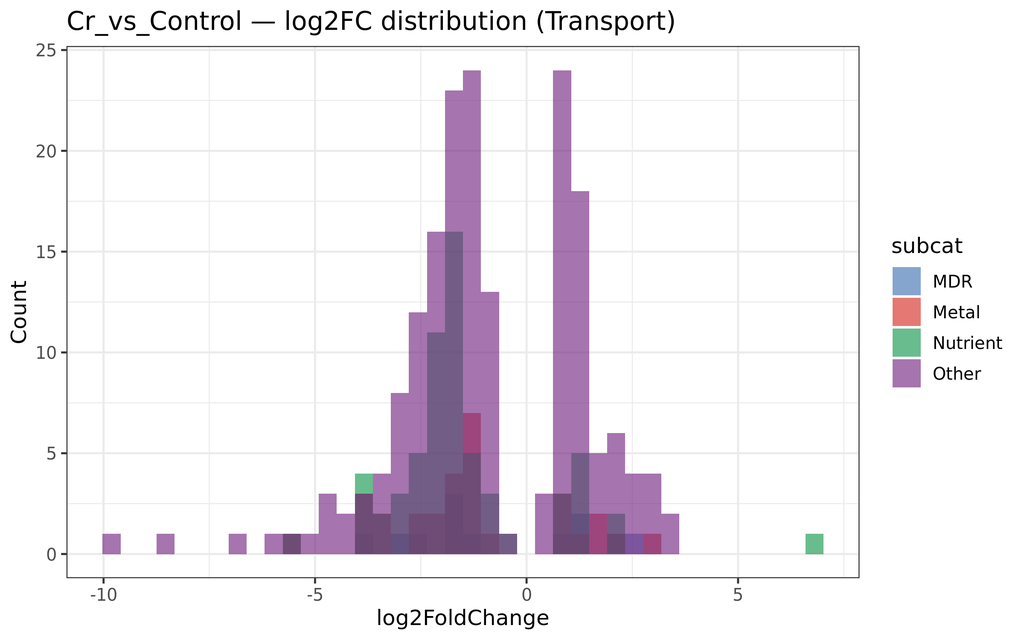

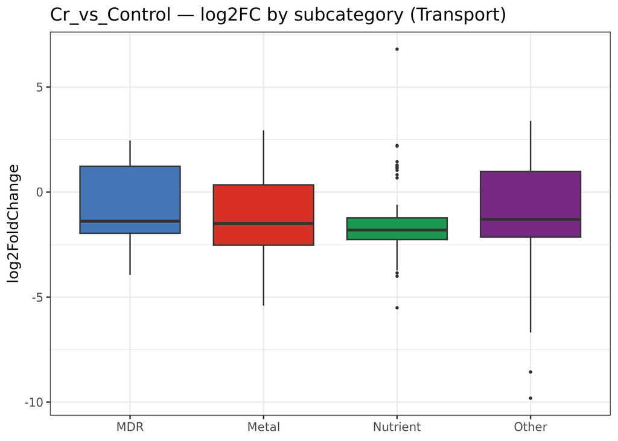

### As_vs_Cr

**Summary:** 288 Transport DEGs. Volcano thresholds: `padj < 0.05` and `|log2FC| ≥ 1`.

[figure not shown]

[figure not shown]

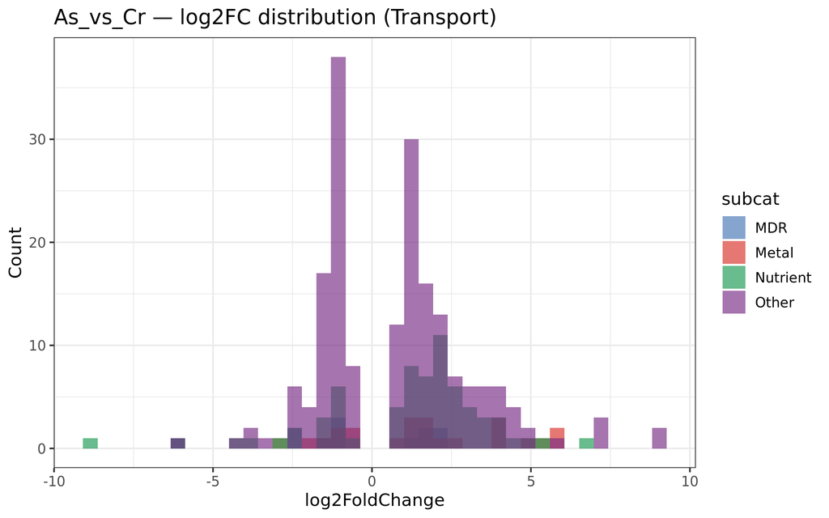

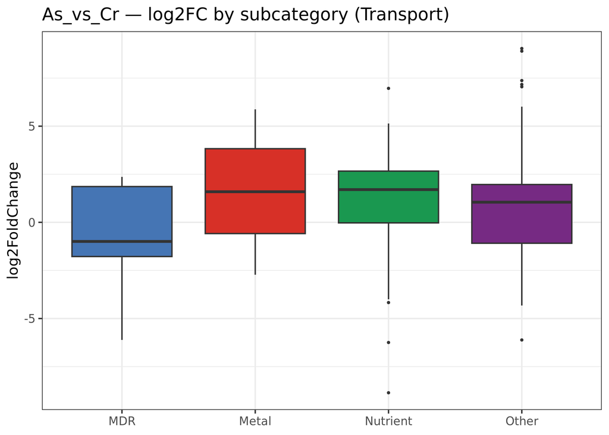

## 3) Auto-generated Results text (descriptive)

### As_vs_Control — Results text

#### Metal

- Top up TSV: As_vs_Control_Metal_top_up.tsv
- Top down TSV: As_vs_Control_Metal_top_down.tsv

**Most up-regulated (top 4):** gene-IR01_06662 (log2FC=7.13; padj=1e-05); gene-IR01_06660 (log2FC=6.74; padj=2.1e-33); gene-IR01_06661 (log2FC=5.74; padj=0.0042); gene-IR01_03270 (log2FC=1.68; padj=0.0016).

**Most down-regulated (top 4):** gene-IR01_02804 (log2FC=-3.23; padj=1.7e-12); gene-IR01_08378 (log2FC=-2.57; padj=1.5e-10); gene-IR01_03632 (log2FC=-1.91; padj=0.0196); gene-IR01_00927 (log2FC=-1.8; padj=0.0101).

#### MDR

- Top up TSV: As_vs_Control_MDR_top_up.tsv
- Top down TSV: As_vs_Control_MDR_top_down.tsv

#### Nutrient

- Top up TSV: As_vs_Control_Nutrient_top_up.tsv
- Top down TSV: As_vs_Control_Nutrient_top_down.tsv

**Most up-regulated (top 4):** gene-IR01_06290 (log2FC=4.85; padj=2.9e-17); gene-IR01_02645 (log2FC=4.81; padj=1.9e-10); gene-IR01_07997 (log2FC=2.99; padj=1.2e-04); gene-IR01_04574 (log2FC=2.28; padj=2e-06).

**Most down-regulated (top 4):** gene-IR01_03747 (log2FC=-7.39; padj=1.9e-04); gene-IR01_09335 (log2FC=-3.75; padj=0.0118); gene-IR01_02966 (log2FC=-3.59; padj=1.5e-16); gene-IR01_08866 (log2FC=-3.33; padj=1.1e-07).

#### Other

- Top up TSV: As_vs_Control_Other_top_up.tsv
- Top down TSV: As_vs_Control_Other_top_down.tsv

**Most up-regulated (top 4):** gene-IR01_08879 (log2FC=6.8; padj=1.5e-38); gene-IR01_00784 (log2FC=3.06; padj=1.5e-09); gene-IR01_02368 (log2FC=2.9; padj=6.7e-11); gene-IR01_04433 (log2FC=2.81; padj=1.5e-11).

**Most down-regulated (top 4):** gene-IR01_07244 (log2FC=-9.22; padj=9.9e-14); gene-IR01_07245 (log2FC=-6.49; padj=5.9e-04); gene-IR01_01580 (log2FC=-4.8; padj=0.0022); gene-IR01_02172 (log2FC=-3.71; padj=0.0085).

### Cr_vs_Control — Results text

#### Metal

- Top up TSV: Cr_vs_Control_Metal_top_up.tsv
- Top down TSV: Cr_vs_Control_Metal_top_down.tsv

**Most up-regulated (top 4):** gene-IR01_07169 (log2FC=2.93; padj=1e-09); gene-IR01_02233 (log2FC=2.23; padj=7.3e-05); gene-IR01_05725 (log2FC=1.89; padj=3.5e-07); gene-IR01_04410 (log2FC=1.63; padj=4.3e-10).

**Most down-regulated (top 4):** gene-IR01_02175 (log2FC=-5.4; padj=1.1e-19); gene-IR01_02606 (log2FC=-4.04; padj=0.0470); gene-IR01_02804 (log2FC=-4; padj=4.1e-20); gene-IR01_03270 (log2FC=-3.68; padj=1.1e-16).

#### MDR

- Top up TSV: Cr_vs_Control_MDR_top_up.tsv
- Top down TSV: Cr_vs_Control_MDR_top_down.tsv

**Most up-regulated (top 4):** gene-IR01_09307 (log2FC=2.46; padj=2.7e-11); gene-IR01_07705 (log2FC=1.97; padj=3.8e-04); gene-IR01_06636 (log2FC=1.33; padj=0.0314); gene-IR01_03260 (log2FC=1.19; padj=0.0120).

**Most down-regulated (top 4):** gene-IR01_08817 (log2FC=-3.94; padj=0.0014); gene-IR01_01772 (log2FC=-2.94; padj=2.4e-05); gene-IR01_02000 (log2FC=-2.53; padj=2.2e-05); gene-IR01_04149 (log2FC=-1.78; padj=0.0038).

#### Nutrient

- Top up TSV: Cr_vs_Control_Nutrient_top_up.tsv
- Top down TSV: Cr_vs_Control_Nutrient_top_down.tsv

**Most up-regulated (top 4):** gene-IR01_03749 (log2FC=6.81; padj=1.1e-05); gene-IR01_04180 (log2FC=2.22; padj=6.5e-04); gene-IR01_02563 (log2FC=2.19; padj=0.0024); gene-IR01_01059 (log2FC=1.45; padj=0.0137).

**Most down-regulated (top 4):** gene-IR01_00456 (log2FC=-5.51; padj=6.4e-16); gene-IR01_03855 (log2FC=-4.01; padj=0.0290); gene-IR01_04335 (log2FC=-3.85; padj=1.1e-12); gene-IR01_08828 (log2FC=-3.74; padj=2.6e-38).

#### Other

- Top up TSV: Cr_vs_Control_Other_top_up.tsv
- Top down TSV: Cr_vs_Control_Other_top_down.tsv

**Most up-regulated (top 4):** gene-IR01_01393 (log2FC=3.39; padj=0.0029); gene-IR01_04392 (log2FC=3.21; padj=1.5e-45); gene-IR01_02847 (log2FC=3.17; padj=0.0038); gene-IR01_05067 (log2FC=3.08; padj=6.4e-05).

**Most down-regulated (top 4):** gene-IR01_02079 (log2FC=-9.81; padj=0.0076); gene-IR01_05302 (log2FC=-8.56; padj=9e-08); gene-IR01_08167 (log2FC=-6.68; padj=2.6e-25); gene-IR01_04093 (log2FC=-5.87; padj=1.8e-15).

### As_vs_Cr — Results text

#### Metal

- Top up TSV: As_vs_Cr_Metal_top_up.tsv
- Top down TSV: As_vs_Cr_Metal_top_down.tsv

**Most up-regulated (top 4):** gene-IR01_02175 (log2FC=5.88; padj=2.6e-23); gene-IR01_06660 (log2FC=5.67; padj=9.1e-25); gene-IR01_03270 (log2FC=5.35; padj=6.4e-35); gene-IR01_06662 (log2FC=5.05; padj=4.4e-04).

**Most down-regulated (top 4):** gene-IR01_02233 (log2FC=-2.72; padj=5.8e-07); gene-IR01_05725 (log2FC=-1.85; padj=4.9e-07); gene-IR01_07169 (log2FC=-1.38; padj=0.0048); gene-IR01_08378 (log2FC=-1; padj=0.0149).

#### MDR

- Top up TSV: As_vs_Cr_MDR_top_up.tsv
- Top down TSV: As_vs_Cr_MDR_top_down.tsv

**Most up-regulated (top 4):** gene-IR01_01772 (log2FC=2.36; padj=7.9e-04); gene-IR01_05349 (log2FC=2.19; padj=4.5e-08); gene-IR01_04149 (log2FC=1.87; padj=0.0020); gene-IR01_02000 (log2FC=1.86; padj=0.0022).

**Most down-regulated (top 4):** gene-IR01_08725 (log2FC=-6.11; padj=0.0452); gene-IR01_09307 (log2FC=-2.38; padj=3.9e-11); gene-IR01_03260 (log2FC=-2.35; padj=1.8e-07); gene-IR01_07705 (log2FC=-1.58; padj=0.0043).

#### Nutrient

- Top up TSV: As_vs_Cr_Nutrient_top_up.tsv
- Top down TSV: As_vs_Cr_Nutrient_top_down.tsv

**Most up-regulated (top 4):** gene-IR01_02645 (log2FC=6.97; padj=5e-19); gene-IR01_06290 (log2FC=5.14; padj=8.5e-24); gene-IR01_08828 (log2FC=4.74; padj=9.3e-62); gene-IR01_01152 (log2FC=4.47; padj=1.8e-08).

**Most down-regulated (top 4):** gene-IR01_03747 (log2FC=-8.86; padj=3.4e-07); gene-IR01_01872 (log2FC=-6.25; padj=0.0018); gene-IR01_09335 (log2FC=-4.17; padj=8.7e-04); gene-IR01_04180 (log2FC=-4; padj=1.2e-08).

#### Other

- Top up TSV: As_vs_Cr_Other_top_up.tsv
- Top down TSV: As_vs_Cr_Other_top_down.tsv

**Most up-regulated (top 4):** gene-IR01_08879 (log2FC=9.04; padj=1.2e-50); gene-IR01_05302 (log2FC=8.9; padj=1.9e-08); gene-IR01_08167 (log2FC=7.37; padj=6.2e-31); gene-IR01_04093 (log2FC=7.17; padj=8.1e-23).

**Most down-regulated (top 4):** gene-IR01_02172 (log2FC=-6.12; padj=4.5e-08); gene-IR01_07244 (log2FC=-4.32; padj=6.3e-04); gene-IR01_01580 (log2FC=-3.89; padj=0.0051); gene-IR01_02251 (log2FC=-3.62; padj=2.5e-23).

### As_vs_Control

#### Metal

- Top up TSV: As_vs_Control_Metal_top_up.tsv
- Top down TSV: As_vs_Control_Metal_top_down.tsv

#### MDR

- Top up TSV: As_vs_Control_MDR_top_up.tsv
- Top down TSV: As_vs_Control_MDR_top_down.tsv

#### Nutrient

- Top up TSV: As_vs_Control_Nutrient_top_up.tsv
- Top down TSV: As_vs_Control_Nutrient_top_down.tsv

#### Other

- Top up TSV: As_vs_Control_Other_top_up.tsv
- Top down TSV: As_vs_Control_Other_top_down.tsv

### Cr_vs_Control

#### Metal

- Top up TSV: Cr_vs_Control_Metal_top_up.tsv
- Top down TSV: Cr_vs_Control_Metal_top_down.tsv

#### MDR

- Top up TSV: Cr_vs_Control_MDR_top_up.tsv
- Top down TSV: Cr_vs_Control_MDR_top_down.tsv

#### Nutrient

- Top up TSV: Cr_vs_Control_Nutrient_top_up.tsv
- Top down TSV: Cr_vs_Control_Nutrient_top_down.tsv

#### Other

- Top up TSV: Cr_vs_Control_Other_top_up.tsv
- Top down TSV: Cr_vs_Control_Other_top_down.tsv

### As_vs_Cr

#### Metal

- Top up TSV: As_vs_Cr_Metal_top_up.tsv
- Top down TSV: As_vs_Cr_Metal_top_down.tsv

#### MDR

- Top up TSV: As_vs_Cr_MDR_top_up.tsv
- Top down TSV: As_vs_Cr_MDR_top_down.tsv

#### Nutrient

- Top up TSV: As_vs_Cr_Nutrient_top_up.tsv
- Top down TSV: As_vs_Cr_Nutrient_top_down.tsv

#### Other

- Top up TSV: As_vs_Cr_Other_top_up.tsv
- Top down TSV: As_vs_Cr_Other_top_down.tsv